# STAT/MATH 495: Problem Set 02

Jonathan Che, Tim Lee, Sarah Teichman

2017-09-19

# Exploratory Data Analysis (EDA)

As 20-something-year-old college students, we don’t know a whole lot about real estate. We do know, however, that we consistently hear three mantras on the subject: “Location, location, location”, “… the housing market…”, and something along the lines of “I want a nice house”. As such, we focus in our EDA on measures of location quality, time, and house quality.

First, we look at the distribution for the price variable, which we are trying to predict.

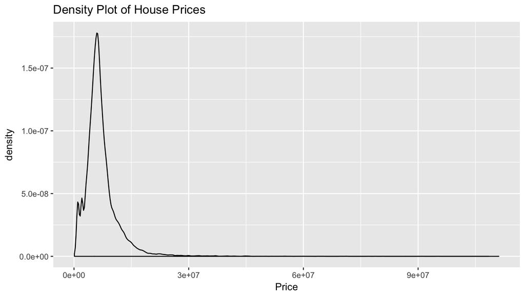

```r
ggplot(train,aes(x=price_doc))+geom_density(aes(y=..density..))+ggtitle("Density Plot of House Prices")+xlab("Price")
```

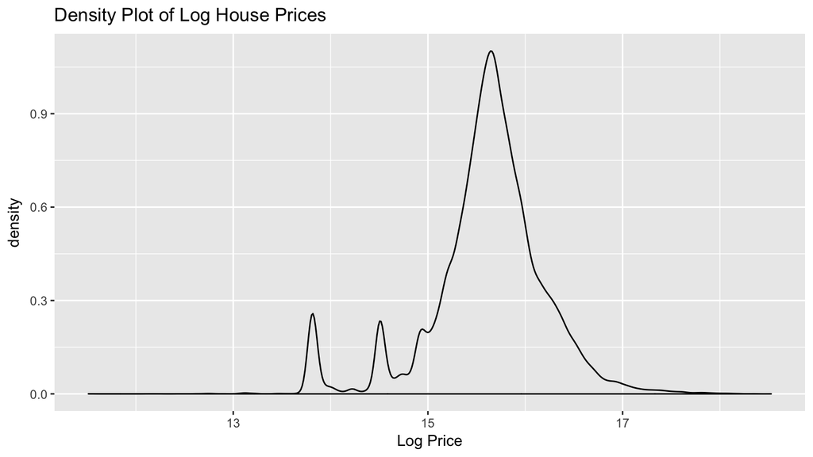

```r
ggplot(train,aes(x=log(price_doc)))+geom_density(aes(y=..density..))+ggtitle("Density Plot of Log House Prices")+xlab("Log Price")
```

We noticed that the price variable has a significant right skew. We did a log transformation, which made the price distribution more centered. However, since we are using this data for prediction and not inference, we decided to use the unchanged skewed price variable in our modeling.

Before we get into looking at specific variables, we examine the correlations of each given (numeric) variable with house price as a sort of sanity check.

```r
# Find which variable has the highest correlation with price_doc
corList <- c()
for(i in 1:(length(names(train)) -1 )){
  if(class(train[[i]]) == "integer" | class(train[[i]]) == "numeric"){
    val <- cor(x = train[[i]], y = train[["price_doc"]])
    corList <- c(corList, val)
  }
  else{ # If correlation is not possible, a 0 is placed so that the correlation matches with the column name
    val <- 0
    corList <- c(corList, val)
  }
}

corListMatched <- data.frame(names(train)[-292], corList) %>%
  filter(abs(corList) > 0.2)
corListMatched <- corListMatched[order(-abs(corListMatched$corList)), ]
corListMatched[1:7,]
```

```
##    names.train...292.    corList
## 1             full_sq  0.3418405
## 41   sport_count_5000  0.2948641
## 26   sport_count_3000  0.2906506
## 29     trc_count_5000  0.2893709
## 7  zd_vokzaly_avto_km -0.2840686
## 4          sadovoe_km -0.2836215
## 6          kremlin_km -0.2792493
```

We notice that the general “house quality” measure `full_sq` seems to be highly correlated with house price. Another “house quality” variable that should be important is `state`, which measures the condition of the house.

```r
train %>%
  group_by(state) %>%
  summarize(avg_price = mean(price_doc))
```

```
## # A tibble: 6 x 2
##   state avg_price
##   <chr>     <dbl>
## 1     1   7315440
## 2     2   7060064
## 3     3   8078316
## 4    33   9000000
## 5     4  13345469
## 6  <NA>   6479556
```

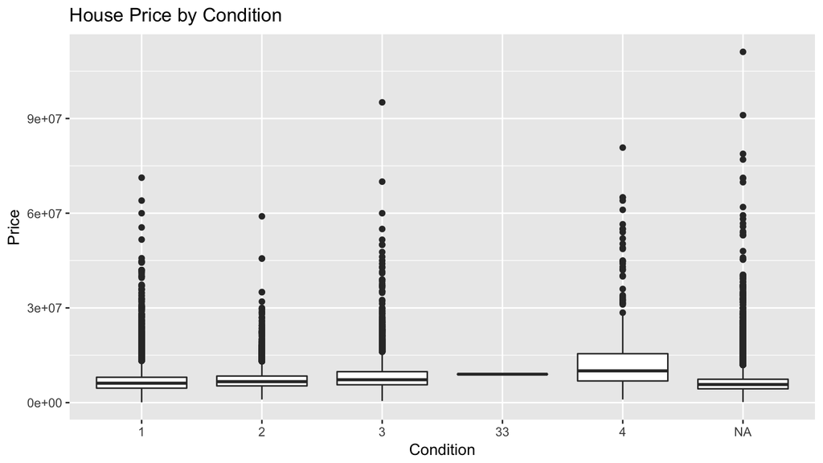

```r
ggplot(train, aes(x=state, y=price_doc)) +
  geom_boxplot() +# state 4 has more expensive houses, NA has cheapest houses (in general)
  ggtitle("House Price by Condition")+xlab("Condition")+ylab("Price")
```

Clearly, houses that are in better condition (i.e. state 4) are more expensive. (33 is most likely a data input error, NAs may even be partially due to purposeful non-reporting). We have not conducted further analysis on this because we did not use it in our spline model, but the large difference in average prices is still interesting to note.

Many location-based variables, such as the number of sports facilities nearby or distance from the Kremlin, were also quite strongly related to house price as well.

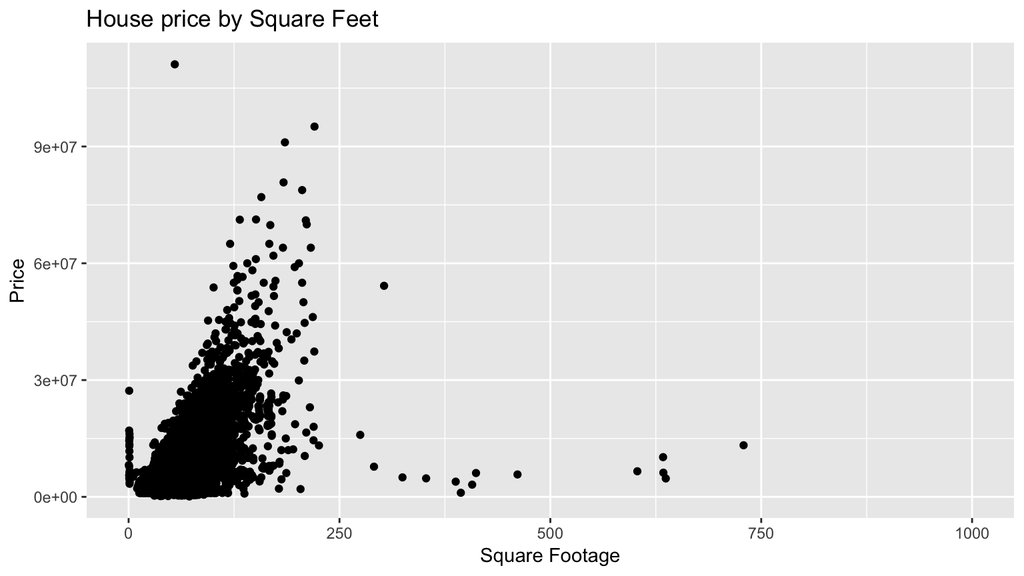

```r
ggplot(train, aes(x=full_sq, y=price_doc)) +
  scale_x_continuous(limits = c(0, 1000)) +
  geom_jitter() +  # price is correlated with square footage
  ggtitle("House price by Square Feet")+xlab("Square Footage")+ylab("Price")
```

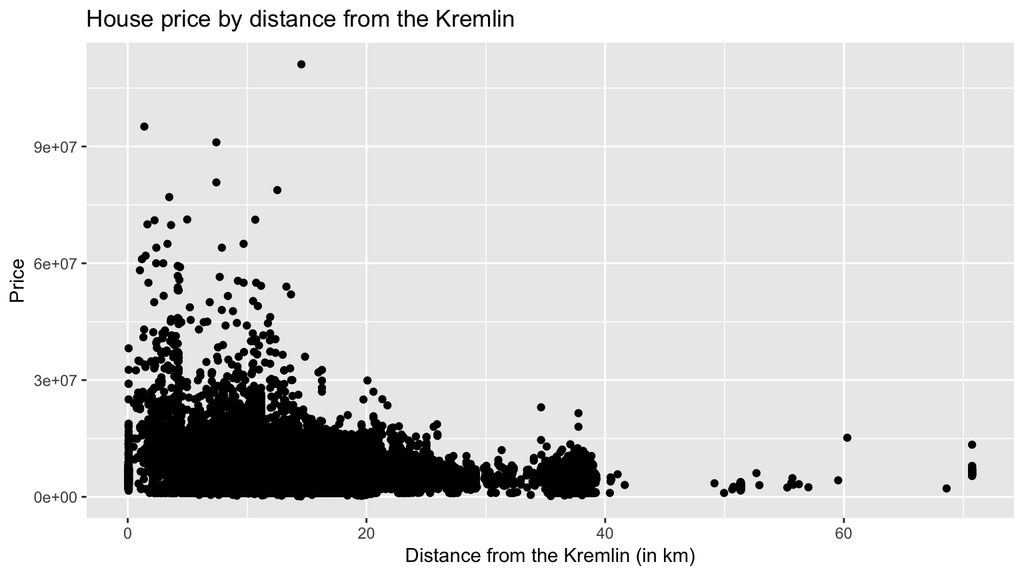

```r
ggplot(train,aes(x=kremlin_km,y=price_doc)) +
  geom_point() + # price is inversely related with distance from the Kremlin
  ggtitle("House price by distance from the Kremlin") + xlab("Distance from the Kremlin (in km)")+ylab("Price")
```

We suppose that location-based variables should be highly related to each other. In other words, they should generally indicate “distance from city center,” or something along those lines.

Finally, we examine mean house prices over time to see if there are highly significant market trends.

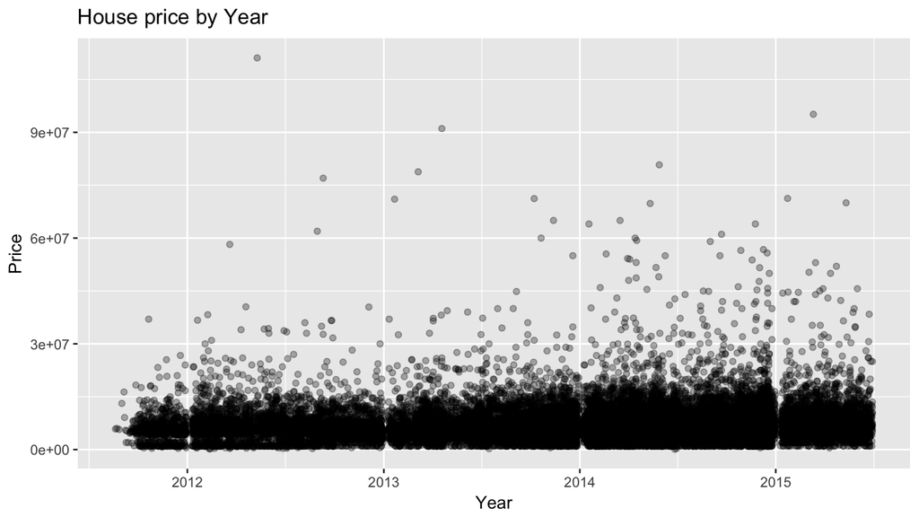

```r
ggplot(train, aes(x=timestamp, y=price_doc)) +
  geom_point(alpha=0.3) + ggtitle("House price by Year")+xlab("Year")+ylab("Price")
```

```r
train %>%
  group_by(year(timestamp)) %>%
  summarize(price = mean(price_doc))
```

```
## # A tibble: 5 x 2
##   `year(timestamp)`   price
##               <dbl>   <dbl>
## 1              2011 5929668
## 2              2012 6354435
## 3              2013 6712150
## 4              2014 7449468
## 5              2015 8183914
```

We notice that average house prices indeed increase over time (inflation!).

To fit a simple spline model, though, without any multivariate or GAM shenanigans, we can only use one numeric variable. Many of the measures that we’ve examined, though, are highly significant.

```r
model <- lm(price_doc~state+timestamp+kremlin_km+full_sq,data=train)
summary(model)
```

```
##
## Call:
## lm(formula = price_doc ~ state + timestamp + kremlin_km + full_sq,
##     data = train)
##
## Residuals:
##       Min        1Q    Median        3Q       Max
## -89345118  -1025315    285098   1280806  60269898
##
## Coefficients:
##               Estimate Std. Error t value Pr(>|t|)
## (Intercept) -2.654e+07  2.457e+06 -10.802  < 2e-16 ***
## state2       5.940e+05  7.372e+04   8.057 8.33e-16 ***
## state3       1.213e+06  7.223e+04  16.786  < 2e-16 ***
## state33      4.077e+06  3.514e+06   1.161    0.246
## state4       4.166e+06  1.796e+05  23.197  < 2e-16 ***
## timestamp    1.725e+03  1.507e+02  11.451  < 2e-16 ***
## kremlin_km  -1.589e+05  3.387e+03 -46.916  < 2e-16 ***
## full_sq      1.451e+05  1.298e+03 111.800  < 2e-16 ***
## ---
## Signif. codes:  0 '***' 0.001 '**' 0.01 '*' 0.05 '.' 0.1 ' ' 1
##
## Residual standard error: 3512000 on 16904 degrees of freedom
##   (13559 observations deleted due to missingness)
## Multiple R-squared:  0.5007, Adjusted R-squared:  0.5005
## F-statistic:  2422 on 7 and 16904 DF,  p-value: < 2.2e-16
```

Ultimately, we choose to just use `full_sq` because of the strength of its relationship to house price.

# Model Fit

Now, we have to decide how much “wiggle” to give our spline model.

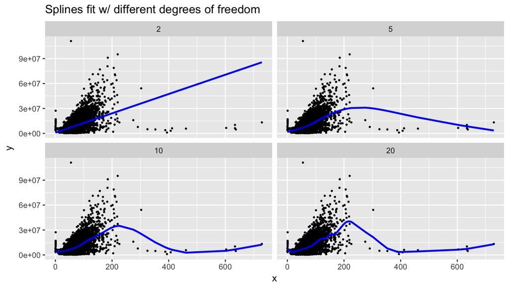

```r
train2 <- train %>%
  filter(full_sq < 1000)   # remove one outlier at 4000 square feet

# Modified from https://gist.github.com/rudeboybert/752f7aa1e42faa2174822dd29bfaf959
df_values <- c(2, 5, 10, 20)
overall <- NULL
for(df in df_values){
  overall <- smooth.spline(train2$full_sq, train2$price_doc, df=df) %>%
    broom::augment() %>%
    mutate(df=df) %>%
    bind_rows(overall)
}
overall <- overall %>%
  as_tibble()
multiple_df <- overall %>%
  ggplot(aes(x=x)) +
  geom_point(aes(y=y), size=0.5) +
  geom_line(aes(y=.fitted), col="blue", size=1) +
  facet_wrap(~df, nrow=2) +
  labs(title="Splines fit w/ different degrees of freedom")
multiple_df
```

By just qualitatively examining different degrees of freedom, it seems like something between 5 and 10 degrees of freedom gives a good general fit.

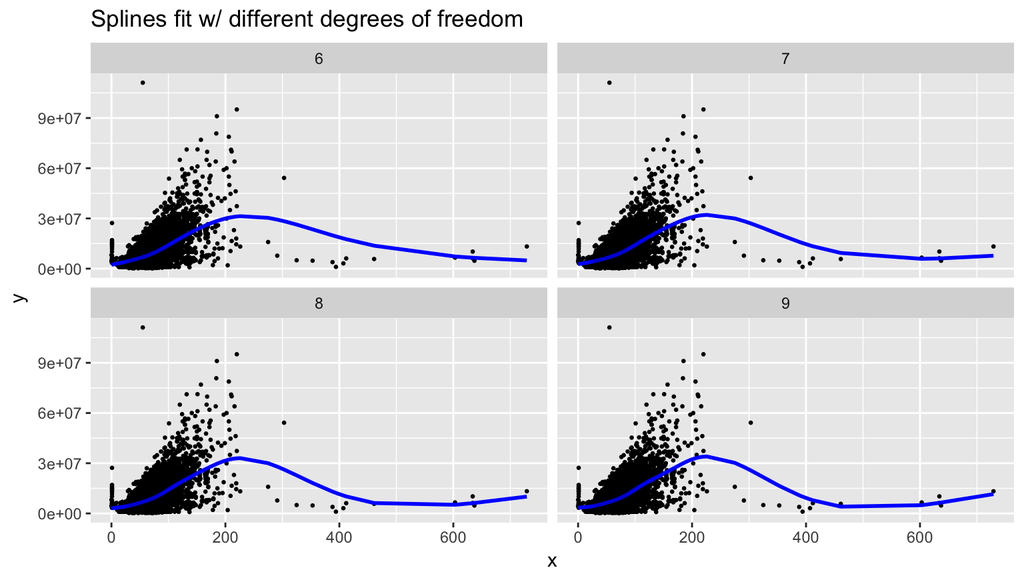

```r
df_values <- c(6,7,8,9)
overall <- NULL
for(df in df_values){
  overall <- smooth.spline(train2$full_sq, train2$price_doc, df=df) %>%
    broom::augment() %>%
    mutate(df=df) %>%
    bind_rows(overall)
}
overall <- overall %>%
  as_tibble()
multiple_df <- overall %>%
  ggplot(aes(x=x)) +
  geom_point(aes(y=y), size=0.5) +
  geom_line(aes(y=.fitted), col="blue", size=1) +
  facet_wrap(~df, nrow=2) +
  labs(title="Splines fit w/ different degrees of freedom")
multiple_df
```

We will use 7 degrees of freedom in our submission.

# Create Submission File

```r
model <- smooth.spline(train2$full_sq, train2$price_doc, df=7)
preds <- predict(model, test$full_sq)
submission <- data.frame(test$id, preds$y)
names(submission) <- c("id", "price_doc")
write.csv(submission, "submission.csv", row.names=FALSE)
```